# Mussismilia hispida

Silas

24/04/2020

# Escolha das variáveis

Selecionei um set de 12 variáveis que considerei importante para a distribuição dos corais. Considerando suas variações, totalizou 29 variáveis

```
##                       V1
## 1             BO_calcite
## 2         BO2_chlomax_ss
## 3        BO2_chlomean_ss
## 4         BO2_chlomin_ss
## 5       BO2_chlorange_ss
## 6            BO_cloudmax
## 7           BO_cloudmean
## 8            BO_cloudmin
## 9               BO_damax
## 10             BO_damean
## 11              BO_damin
## 12     BO2_nitratemax_ss
## 13    BO2_nitratemean_ss
## 14     BO2_nitratemin_ss
## 15   BO2_nitraterange_ss
## 16             BO_parmax
## 17            BO_parmean
## 18                 BO_ph
## 19   BO2_phosphatemax_ss
## 20  BO2_phosphatemean_ss
## 21   BO2_phosphatemin_ss
## 22 BO2_phosphaterange_ss
## 23   BO2_salinitymean_ss
## 24   BO2_silicatemean_ss
## 25        BO2_tempmax_ss
## 26       BO2_tempmean_ss
## 27        BO2_tempmin_ss
## 28      BO2_temprange_ss
## 29     BO2_curvelmean_ss
```

Depois utilizei o `vifstep` para selecionar as variáveis com menor correlação (VIF < 10).

1. Usando todas as variáveis escolhidas pelo `vifstep`. Isso incluí variações da mesma variável (e.g. **cloudmax** e **cloudmin**)
2. Usando as variáveis escolhidas pelo `vifstep` e removendo variações da mesma variável. **Nesse caso, as com maior VIF**.
3. Usando as variáveis escolhidas pelo `vifstep` e removendo variações da mesma variável. **Nesse caso, as que para mim teriam menor efeito biológico (e.g. remover cloudmin e ficar com cloudmax)**.
4. Escolhendo manualmente só as variáveis com forte efeito fisiológico. No caso: *parmax*, *salinitymean*, *tempmax*. Fiz isso por conta desse artigo:

*Gardner AS, Maclean IMD, Gaston KJ (2019) Climatic predictors of species distributions neglect biophysiologically meaningful variables. Divers Distrib 25:1318–1333*

5. Também testei rodar um modelo e remover as variáveis que tiveram menor importância. A ideia era tentar simplificar o modelo, o que facilita explicá-lo. Utilizei o método desse artigo:

*Naimi B, Hamm NAS, Groen TA, Skidmore AK, Toxopeus AG (2014) Where is positional uncertainty a problem for species distribution modelling? Ecography (Cop) 37:191–203*

No caso, remove-se aquelas que tiveram importância menor que 0.05.

## Modelagem

Utilizei modelos que usam presença/pseudo-ausência (e depois implementei Maxent com presença somente - explicação no final):

| Abreviação | Nome do modelo |
| --- | --- |
| RF | Random Forest |
| BRT | Boosted Regression Trees |
| GLM | Generalized Linear Model |
| GAM | Generalized Aditive Model |

> **Pseudo-ausências**

> As pseudo-ausências foram geradas utilizando uma base biológica, ao invés do método completamente aleatório. Primeiro, 20000 pontos foram gerados aleatoriamente sobre a área de estudo. Depois, removi os pontos que caíam dentro de um buffer de 50km ao redor dos pontos que já tínhamos. Depois selecionei todos os pontos que caíam em áreas entre -50 e -100m de profundidade (PA_batimetria) e excluí para que não fossem selecionados novamente. Em seguida selecionei os pontos que ocorrem em áreas com fundo não consolidado, usando uma camada litográfica (PA_lito). Os pontos restantes, não selecionados, compuseram o conjunto aleatório (PA_random). Os conjuntos finais de pseudo-ausência foram gerados com 30% de pontos do PA_batimetria, 30% do PA_lito e 40% do PA_random. Essas porcentagens foram estabelecidas pela relação entre os pontos sorteados em cada método X pontos totais fora do buffer. Foram gerados 10 conjuntos únicos de pseudo-ausências, ou seja, sem repetição.

Rodei os modelos utilizando o `BIOMOD2`. Foram realizados 5 réplicas por conjunto de pseudo-ausência, por tipo de modelo (gerando um total de 200 modelos). A importância das variáveis foi aferida com 30 permutações.

No final foi feito um ensemble usando o método Comitee Averaging:

> *To do this model, the probabilities from the selected models are first transformed into binary data according to the thresholds defined at BIOMOD_Modeling step (maximizing evaluation metric score over ‘testing dataset’ ). The committee averaging score is then the average of binary predictions. It is built on the analogy of a simple vote. Each model vote for the species being ether present or absent. For each site, the sum of 1 is then divided by the number of models. The interesting feature of this measure is that it gives both a prediction and a measure of uncertainty. When the prediction is close to 0 or 1, it means that all models agree to predict 0 and 1 respectively. When the prediction is around 0.5, it means that half the models predict 1 and the other half 0.*

Para o ensemble utilizei só os modelos com TSS > 0.85.

Abaixo apresento os resultados para cada método de escolha das variáveis. Mostro:

1. Binários do modelo com maior TSS para cada algoritmo
2. Ensemble na escala 0:1
3. Ensemble binário: selecionei como threshold o ponto em que 70% dos modelos concordam com presença (0.7)
4. Modelos Presence-only
5. Tabela de métricas (bastante informação!)
6. Tabela de importância das variáveis (bastante informação!)

### Modelo 1

Usando todas as variáveis escolhidas pelo `vifstep`. Isso incluí variações da mesma variável (e.g. **cloudmax** e **cloudmin**)

#### Binários

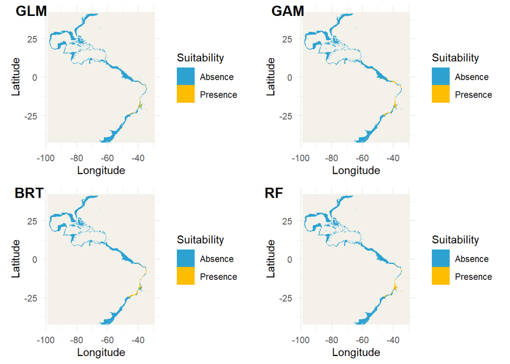

#### Ensemble escala 0:1

[interactive chart not shown]

#### Ensemble binário

[interactive chart not shown]

### Modelo 2

Usando as variáveis escolhidas pelo `vifstep` e removendo variações da mesma variável. **Nesse caso, as com maior VIF**.

**Na minha visão, esse foi o modelo de melhor performance.**

#### Binários

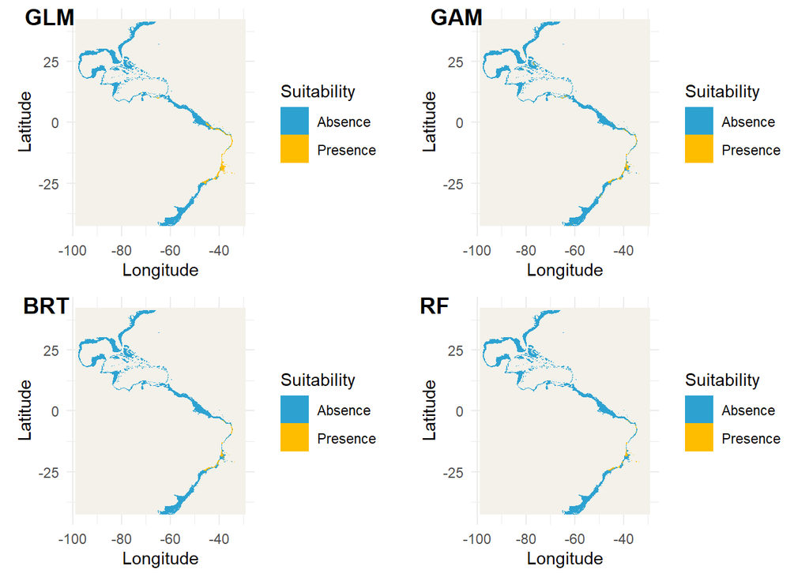

#### Ensemble escala 0:1

[interactive chart not shown]

#### Ensemble binário

[interactive chart not shown]

### Modelo 3

Usando as variáveis escolhidas pelo `vifstep` e removendo variações da mesma variável. **Nesse caso, as que para mim teriam menor efeito biológico (e.g. remover cloudmin e ficar com cloudmax)**.

#### Binários

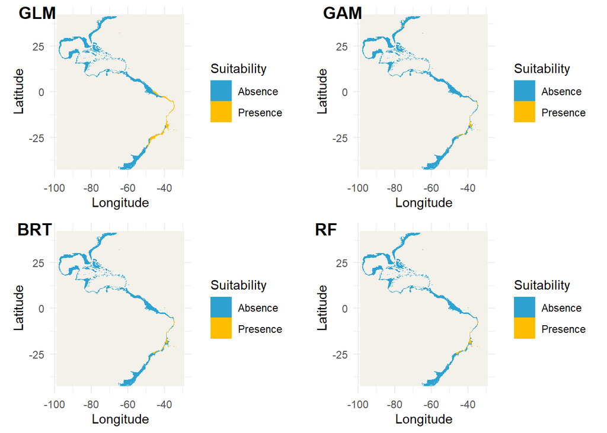

#### Ensemble escala 0:1

[interactive chart not shown]

#### Ensemble binário

[interactive chart not shown]

### Modelo 4

Escolhendo manualmente só as variáveis com forte efeito fisiológico. No caso: *parmax*, *salinitymean*, *tempmax*.

#### Binários

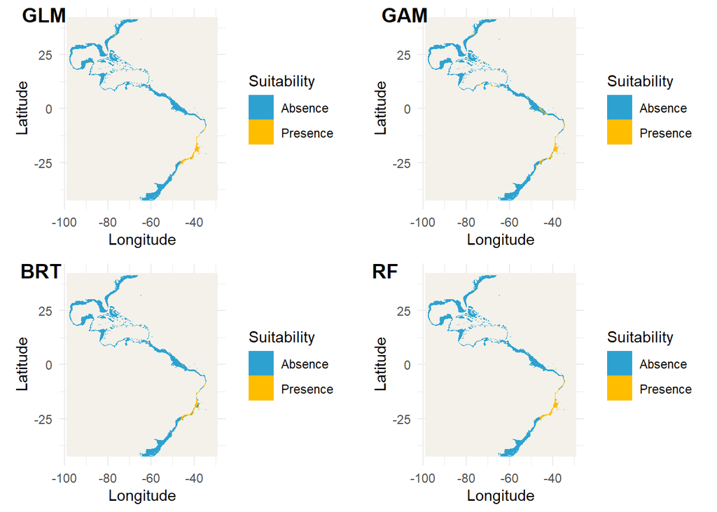

#### Ensemble escala 0:1

[interactive chart not shown]

#### Ensemble binário

[interactive chart not shown]

### Modelo 5

Também testei rodar um modelo e remover as variáveis que tiveram menor importância. A ideia era tentar simplificar o modelo, o que facilita explicá-lo. Para isso usei a função `get_variables_importance` do pacote `biomod` no ensemble. No caso, remove-se aquelas que tiveram importância menor que 0.05. Fiz isso com base no Modelo 2, que para mim foi o de melhor performance.

#### Binários

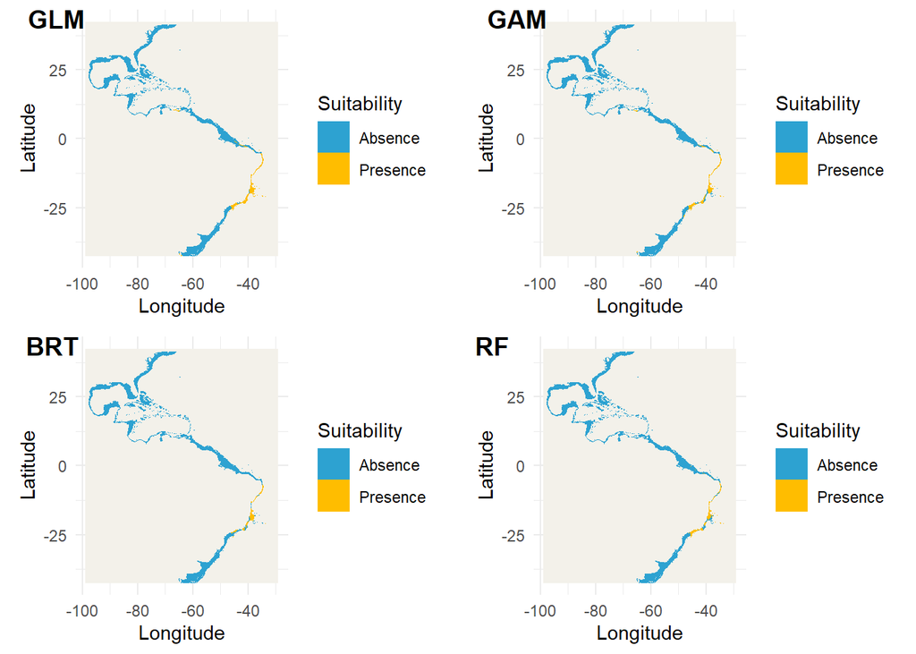

#### Ensemble escala 0:1

[interactive chart not shown]

#### Ensemble binário

[interactive chart not shown]

### Modelos presence-only

Eu também testei os dados no Maxent (um modelo Presence/background) para ver se os resultados concordavam com os dos modelos Presence/Pseudo-absence.

Implementei o modelo no Maxent mesmo (pelo Biomod os resultados estavam estranhos), com 10 réplicas.

Também fiz uma implementação do MIAmaxent. Este é um modelo relativamente novo, com melhorias lançadas no último ano. Ele usa a mesma ideia do Maxent, mas permite maior controle sobre o uso de transformações das variáveis no modelo final. Eu ainda estou aprendendo a mexer nele, então os resultados não foram tão bons. Mas achei bastante promissor.

Para o Maxent exibo: (1) Mapa original com a média de todos os modelos, (2) Ensemble dos Binários (maxSSS) - comitee averaging >0.8 (80% dos modelos concordam)

Para o MIAmaxent exibo: (1) Mapa original em escala PRO, (2) binário que maximiza o TSS

#### Maxent

##### Média modelos

[interactive chart not shown]

##### Ensemble binários

[interactive chart not shown]

#### MIAmaxent

##### Mapa original

[interactive chart not shown]

##### Binário maior TSS

[interactive chart not shown]

### Tabelas de métricas

Modelo 1

| Model.name | Eval.metric | Testing.data | Evaluating.data | Cutoff | Sensitivity | Specificity |
| --- | --- | --- | --- | --- | --- | --- |
| RF_RUN1_PA1 | TSS | 0.989 | NA | 292.0 | 100.000 | 98.868 |
| RF_RUN1_PA1 | ROC | 0.997 | NA | NA | NA | NA |
| RF_RUN1_PA1 | KAPPA | 0.940 | NA | 292.0 | 100.000 | 98.868 |
| GBM_RUN1_PA1 | TSS | 0.981 | NA | 442.0 | 100.000 | 98.113 |
| GBM_RUN1_PA1 | ROC | 0.996 | NA | NA | NA | NA |
| GBM_RUN1_PA1 | KAPPA | 0.918 | NA | 502.0 | 96.154 | 98.868 |
| GLM_RUN1_PA1 | TSS | 0.955 | NA | 495.0 | 100.000 | 95.472 |
| GLM_RUN1_PA1 | ROC | 0.977 | NA | NA | NA | NA |
| GAM_RUN1_PA1 | ROC | 0.873 | NA | NA | NA | NA |
| RF_RUN2_PA1 | TSS | 0.974 | NA | 348.5 | 100.000 | 97.358 |
| RF_RUN2_PA1 | ROC | 0.996 | NA | NA | NA | NA |
| RF_RUN2_PA1 | KAPPA | 0.896 | NA | 460.0 | 92.308 | 98.868 |
| GBM_RUN2_PA1 | TSS | 0.970 | NA | 444.0 | 100.000 | 96.981 |
| GBM_RUN2_PA1 | ROC | 0.995 | NA | NA | NA | NA |
| GBM_RUN2_PA1 | KAPPA | 0.873 | NA | 768.0 | 88.462 | 98.868 |
| GLM_RUN2_PA1 | TSS | 0.906 | NA | 495.0 | 100.000 | 90.566 |
| GLM_RUN2_PA1 | ROC | 0.953 | NA | NA | NA | NA |
| GAM_RUN2_PA1 | TSS | 0.858 | NA | 20.0 | 88.462 | 97.358 |
| GAM_RUN2_PA1 | ROC | 0.929 | NA | NA | NA | NA |
| RF_RUN3_PA1 | TSS | 0.928 | NA | 283.0 | 96.154 | 96.604 |
| RF_RUN3_PA1 | ROC | 0.993 | NA | NA | NA | NA |
| RF_RUN3_PA1 | KAPPA | 0.869 | NA | 631.0 | 84.615 | 99.245 |
| GBM_RUN3_PA1 | TSS | 0.931 | NA | 562.5 | 96.154 | 96.981 |
| GBM_RUN3_PA1 | ROC | 0.992 | NA | NA | NA | NA |
| GBM_RUN3_PA1 | KAPPA | 0.859 | NA | 669.0 | 92.308 | 98.113 |
| GLM_RUN3_PA1 | TSS | 0.909 | NA | 495.0 | 96.154 | 94.717 |
| GLM_RUN3_PA1 | ROC | 0.954 | NA | NA | NA | NA |
| GAM_RUN3_PA1 | TSS | 0.885 | NA | 0.0 | 100.000 | 0.000 |
| GAM_RUN3_PA1 | ROC | 0.944 | NA | NA | NA | NA |
| RF_RUN4_PA1 | TSS | 0.924 | NA | 335.0 | 96.154 | 96.226 |

[output cut: 405 more lines]

Modelo 2

| Model.name | Eval.metric | Testing.data | Evaluating.data | Cutoff | Sensitivity | Specificity |
| --- | --- | --- | --- | --- | --- | --- |
| RF_RUN1_PA1 | TSS | 0.966 | NA | 217.0 | 100.000 | 96.604 |
| RF_RUN1_PA1 | ROC | 0.997 | NA | NA | NA | NA |
| RF_RUN1_PA1 | KAPPA | 0.918 | NA | 323.0 | 96.154 | 98.868 |
| GBM_RUN1_PA1 | TSS | 0.935 | NA | 382.0 | 96.154 | 97.358 |
| GBM_RUN1_PA1 | ROC | 0.993 | NA | NA | NA | NA |
| GBM_RUN1_PA1 | KAPPA | 0.878 | NA | 511.0 | 92.308 | 98.491 |
| GLM_RUN1_PA1 | ROC | 0.889 | NA | NA | NA | NA |
| GAM_RUN1_PA1 | ROC | 0.890 | NA | NA | NA | NA |
| RF_RUN2_PA1 | TSS | 0.947 | NA | 95.0 | 100.000 | 94.717 |
| RF_RUN2_PA1 | ROC | 0.993 | NA | NA | NA | NA |
| RF_RUN2_PA1 | KAPPA | 0.893 | NA | 443.0 | 88.462 | 99.245 |
| GBM_RUN2_PA1 | TSS | 0.928 | NA | 84.0 | 100.000 | 92.830 |
| GBM_RUN2_PA1 | ROC | 0.990 | NA | NA | NA | NA |
| GBM_RUN2_PA1 | KAPPA | 0.850 | NA | 511.0 | 84.615 | 98.868 |
| GLM_RUN2_PA1 | ROC | 0.887 | NA | NA | NA | NA |
| RF_RUN3_PA1 | TSS | 0.962 | NA | 141.0 | 100.000 | 96.226 |
| RF_RUN3_PA1 | ROC | 0.994 | NA | NA | NA | NA |
| RF_RUN3_PA1 | KAPPA | 0.916 | NA | 392.0 | 92.308 | 99.245 |
| GBM_RUN3_PA1 | TSS | 0.955 | NA | 175.5 | 100.000 | 95.472 |
| GBM_RUN3_PA1 | ROC | 0.992 | NA | NA | NA | NA |
| GBM_RUN3_PA1 | KAPPA | 0.878 | NA | 402.0 | 92.308 | 98.491 |
| GLM_RUN3_PA1 | ROC | 0.912 | NA | NA | NA | NA |
| GAM_RUN3_PA1 | ROC | 0.893 | NA | NA | NA | NA |
| RF_RUN4_PA1 | TSS | 0.958 | NA | 146.0 | 100.000 | 95.849 |
| RF_RUN4_PA1 | ROC | 0.994 | NA | NA | NA | NA |
| RF_RUN4_PA1 | KAPPA | 0.896 | NA | 442.0 | 92.308 | 98.868 |
| GBM_RUN4_PA1 | TSS | 0.925 | NA | 83.0 | 100.000 | 92.075 |
| GBM_RUN4_PA1 | ROC | 0.990 | NA | NA | NA | NA |
| GBM_RUN4_PA1 | KAPPA | 0.878 | NA | 525.0 | 92.308 | 98.491 |
| GLM_RUN4_PA1 | TSS | 0.889 | NA | 495.0 | 92.308 | 96.604 |

[output cut: 385 more lines]

Modelo 3

| Model.name | Eval.metric | Testing.data | Evaluating.data | Cutoff | Sensitivity | Specificity |
| --- | --- | --- | --- | --- | --- | --- |
| RF_RUN1_PA1 | TSS | 0.951 | NA | 106.0 | 100.000 | 95.094 |
| RF_RUN1_PA1 | ROC | 0.996 | NA | NA | NA | NA |
| RF_RUN1_PA1 | KAPPA | 0.889 | NA | 327.0 | 84.615 | 99.623 |
| GBM_RUN1_PA1 | TSS | 0.940 | NA | 85.0 | 100.000 | 93.962 |
| GBM_RUN1_PA1 | ROC | 0.994 | NA | NA | NA | NA |
| GBM_RUN1_PA1 | KAPPA | 0.889 | NA | 663.0 | 84.615 | 99.623 |
| GLM_RUN1_PA1 | TSS | 0.925 | NA | 262.0 | 100.000 | 92.453 |
| GLM_RUN1_PA1 | ROC | 0.988 | NA | NA | NA | NA |
| GAM_RUN1_PA1 | ROC | 0.902 | NA | NA | NA | NA |
| GAM_RUN1_PA1 | KAPPA | 0.864 | NA | 0.0 | 100.000 | 0.000 |
| RF_RUN2_PA1 | TSS | 0.951 | NA | 120.0 | 100.000 | 95.094 |
| RF_RUN2_PA1 | ROC | 0.994 | NA | NA | NA | NA |
| RF_RUN2_PA1 | KAPPA | 0.889 | NA | 336.0 | 84.615 | 99.623 |
| GBM_RUN2_PA1 | TSS | 0.928 | NA | 80.5 | 100.000 | 92.830 |
| GBM_RUN2_PA1 | ROC | 0.993 | NA | NA | NA | NA |
| GBM_RUN2_PA1 | KAPPA | 0.884 | NA | 874.5 | 80.769 | 100.000 |
| GLM_RUN2_PA1 | TSS | 0.940 | NA | 167.0 | 100.000 | 93.962 |
| GLM_RUN2_PA1 | ROC | 0.993 | NA | NA | NA | NA |
| GLM_RUN2_PA1 | KAPPA | 0.896 | NA | 864.0 | 92.308 | 98.868 |
| GAM_RUN2_PA1 | ROC | 0.899 | NA | NA | NA | NA |
| RF_RUN3_PA1 | TSS | 0.974 | NA | 207.0 | 100.000 | 97.358 |
| RF_RUN3_PA1 | ROC | 0.995 | NA | NA | NA | NA |
| RF_RUN3_PA1 | KAPPA | 0.916 | NA | 530.0 | 92.308 | 99.245 |
| GBM_RUN3_PA1 | TSS | 0.966 | NA | 354.0 | 100.000 | 96.604 |
| GBM_RUN3_PA1 | ROC | 0.993 | NA | NA | NA | NA |
| GBM_RUN3_PA1 | KAPPA | 0.878 | NA | 720.5 | 92.308 | 98.491 |
| GLM_RUN3_PA1 | TSS | 0.851 | NA | 495.0 | 88.462 | 96.604 |
| GLM_RUN3_PA1 | ROC | 0.925 | NA | NA | NA | NA |
| GAM_RUN3_PA1 | ROC | 0.876 | NA | NA | NA | NA |
| RF_RUN4_PA1 | TSS | 0.974 | NA | 121.0 | 100.000 | 97.358 |

[output cut: 392 more lines]

Modelo 4

| Model.name | Eval.metric | Testing.data | Evaluating.data | Cutoff | Sensitivity | Specificity |
| --- | --- | --- | --- | --- | --- | --- |
| RF_RUN1_PA1 | TSS | 0.866 | NA | 189.0 | 92.308 | 94.340 |
| RF_RUN1_PA1 | ROC | 0.984 | NA | NA | NA | NA |
| GBM_RUN1_PA1 | TSS | 0.893 | NA | 725.0 | 92.308 | 96.981 |
| GBM_RUN1_PA1 | ROC | 0.986 | NA | NA | NA | NA |
| GLM_RUN1_PA1 | TSS | 0.878 | NA | 847.0 | 92.308 | 95.472 |
| GLM_RUN1_PA1 | ROC | 0.969 | NA | NA | NA | NA |
| GAM_RUN1_PA1 | ROC | 0.974 | NA | NA | NA | NA |
| RF_RUN2_PA1 | TSS | 0.897 | NA | 100.0 | 96.154 | 93.585 |
| RF_RUN2_PA1 | ROC | 0.985 | NA | NA | NA | NA |
| GBM_RUN2_PA1 | TSS | 0.885 | NA | 558.0 | 92.308 | 96.226 |
| GBM_RUN2_PA1 | ROC | 0.982 | NA | NA | NA | NA |
| GLM_RUN2_PA1 | TSS | 0.874 | NA | 784.0 | 92.308 | 95.094 |
| GLM_RUN2_PA1 | ROC | 0.965 | NA | NA | NA | NA |
| GAM_RUN2_PA1 | TSS | 0.883 | NA | 257.0 | 100.000 | 88.302 |
| GAM_RUN2_PA1 | ROC | 0.973 | NA | NA | NA | NA |
| RF_RUN3_PA1 | TSS | 0.909 | NA | 158.0 | 96.154 | 94.340 |
| RF_RUN3_PA1 | ROC | 0.979 | NA | NA | NA | NA |
| GBM_RUN3_PA1 | TSS | 0.925 | NA | 303.0 | 100.000 | 92.453 |
| GBM_RUN3_PA1 | ROC | 0.982 | NA | NA | NA | NA |
| GLM_RUN3_PA1 | TSS | 0.874 | NA | 737.0 | 92.308 | 94.717 |
| GLM_RUN3_PA1 | ROC | 0.960 | NA | NA | NA | NA |
| GAM_RUN3_PA1 | ROC | 0.976 | NA | NA | NA | NA |
| RF_RUN4_PA1 | TSS | 0.908 | NA | 301.0 | 92.308 | 98.491 |
| RF_RUN4_PA1 | ROC | 0.989 | NA | NA | NA | NA |
| RF_RUN4_PA1 | KAPPA | 0.878 | NA | 301.0 | 92.308 | 98.491 |
| GBM_RUN4_PA1 | TSS | 0.875 | NA | 240.0 | 96.154 | 91.321 |
| GBM_RUN4_PA1 | ROC | 0.983 | NA | NA | NA | NA |
| GLM_RUN4_PA1 | TSS | 0.885 | NA | 784.5 | 92.308 | 96.226 |
| GLM_RUN4_PA1 | ROC | 0.971 | NA | NA | NA | NA |
| GAM_RUN4_PA1 | TSS | 0.867 | NA | 573.0 | 96.154 | 90.566 |

[output cut: 367 more lines]

Modelo 5

| Model.name | Eval.metric | Testing.data | Evaluating.data | Cutoff | Sensitivity | Specificity |
| --- | --- | --- | --- | --- | --- | --- |
| RF_RUN1_PA1 | TSS | 0.932 | NA | 50.0 | 100.000 | 93.208 |
| RF_RUN1_PA1 | ROC | 0.987 | NA | NA | NA | NA |
| GBM_RUN1_PA1 | TSS | 0.890 | NA | 116.0 | 96.154 | 92.830 |
| GBM_RUN1_PA1 | ROC | 0.984 | NA | NA | NA | NA |
| GLM_RUN1_PA1 | TSS | 0.856 | NA | 495.0 | 96.154 | 89.434 |
| GLM_RUN1_PA1 | ROC | 0.928 | NA | NA | NA | NA |
| GAM_RUN1_PA1 | TSS | 0.917 | NA | 10.0 | 100.000 | 91.698 |
| GAM_RUN1_PA1 | ROC | 0.981 | NA | NA | NA | NA |
| RF_RUN2_PA1 | TSS | 0.974 | NA | 393.0 | 100.000 | 97.358 |
| RF_RUN2_PA1 | ROC | 0.997 | NA | NA | NA | NA |
| RF_RUN2_PA1 | KAPPA | 0.916 | NA | 544.0 | 92.308 | 99.245 |
| GBM_RUN2_PA1 | TSS | 0.981 | NA | 837.0 | 100.000 | 98.113 |
| GBM_RUN2_PA1 | ROC | 0.994 | NA | NA | NA | NA |
| GBM_RUN2_PA1 | KAPPA | 0.903 | NA | 837.0 | 100.000 | 98.113 |
| GLM_RUN2_PA1 | ROC | 0.912 | NA | NA | NA | NA |
| GAM_RUN2_PA1 | TSS | 0.958 | NA | 821.0 | 100.000 | 95.849 |
| GAM_RUN2_PA1 | ROC | 0.979 | NA | NA | NA | NA |
| RF_RUN3_PA1 | TSS | 0.917 | NA | 50.0 | 100.000 | 91.698 |
| RF_RUN3_PA1 | ROC | 0.988 | NA | NA | NA | NA |
| GBM_RUN3_PA1 | TSS | 0.921 | NA | 146.0 | 100.000 | 92.075 |
| GBM_RUN3_PA1 | ROC | 0.990 | NA | NA | NA | NA |
| GBM_RUN3_PA1 | KAPPA | 0.850 | NA | 901.0 | 84.615 | 98.868 |
| GLM_RUN3_PA1 | TSS | 0.894 | NA | 288.0 | 100.000 | 89.434 |
| GLM_RUN3_PA1 | ROC | 0.959 | NA | NA | NA | NA |
| GAM_RUN3_PA1 | TSS | 0.909 | NA | 470.0 | 100.000 | 90.943 |
| GAM_RUN3_PA1 | ROC | 0.981 | NA | NA | NA | NA |
| RF_RUN4_PA1 | TSS | 0.932 | NA | 139.0 | 100.000 | 93.208 |
| RF_RUN4_PA1 | ROC | 0.990 | NA | NA | NA | NA |
| GBM_RUN4_PA1 | TSS | 0.890 | NA | 311.0 | 96.154 | 92.830 |
| GBM_RUN4_PA1 | ROC | 0.978 | NA | NA | NA | NA |

[output cut: 413 more lines]

### Tabelas de importância das variáveis

Modelo 1

| X | RF.RUN1.PA1 | GBM.RUN1.PA1 | GLM.RUN1.PA1 | GAM.RUN1.PA1 | RF.RUN2.PA1 | GBM.RUN2.PA1 | GLM.RUN2.PA1 | GAM.RUN2.PA1 | RF.RUN3.PA1 | GBM.RUN3.PA1 | GLM.RUN3.PA1 | GAM.RUN3.PA1 | RF.RUN4.PA1 | GBM.RUN4.PA1 | GLM.RUN4.PA1 | GAM.RUN4.PA1 | RF.RUN5.PA1 | GBM.RUN5.PA1 | GLM.RUN5.PA1 | GAM.RUN5.PA1 | RF.RUN1.PA2 | GBM.RUN1.PA2 | GLM.RUN1.PA2 | GAM.RUN1.PA2 | RF.RUN2.PA2 | GBM.RUN2.PA2 | GLM.RUN2.PA2 | GAM.RUN2.PA2 | RF.RUN3.PA2 | … |
| --- | --- | --- | --- | --- | --- | --- | --- | --- | --- | --- | --- | --- | --- | --- | --- | --- | --- | --- | --- | --- | --- | --- | --- | --- | --- | --- | --- | --- | --- | --- |
| BO_calcite | 0.007 | 0.012 | 0.095 | 0.022 | 0.005 | 0.018 | 0.075 | 0.162 | 0.006 | 0.014 | 0.000 | 0.128 | 0.005 | 0.005 | 0.000 | 0.059 | 0.005 | 0.016 | 0.172 | 0.110 | 0.005 | 0.013 | 0.000 | 0.026 | 0.002 | 0.006 | 0.000 | 0.099 | 0.002 | … |
| BO2_chlomin_ss | 0.003 | 0.000 | 0.401 | 0.449 | 0.004 | 0.000 | 0.000 | 0.073 | 0.004 | 0.000 | 0.000 | 0.149 | 0.003 | 0.000 | 0.000 | 0.202 | 0.005 | 0.000 | 0.238 | 0.181 | 0.005 | 0.003 | 0.059 | 0.246 | 0.006 | 0.005 | 0.044 | 0.154 | 0.007 | … |
| BO2_chlorange_ss | 0.003 | 0.000 | 0.038 | 0.105 | 0.004 | 0.000 | 0.162 | 0.278 | 0.004 | 0.000 | 0.159 | 0.109 | 0.004 | 0.000 | 0.037 | 0.316 | 0.002 | 0.000 | 0.486 | 0.173 | 0.005 | 0.000 | 0.332 | 0.189 | 0.008 | 0.000 | 0.023 | 0.209 | 0.004 | … |
| BO_cloudmax | 0.001 | 0.005 | 0.000 | 0.113 | 0.002 | 0.006 | 0.132 | 0.211 | 0.002 | 0.002 | 0.256 | 0.254 | 0.001 | 0.004 | 0.000 | 0.127 | 0.002 | 0.002 | 0.000 | 0.233 | 0.002 | 0.018 | 0.000 | 0.351 | 0.001 | 0.008 | 0.096 | 0.305 | 0.001 | … |
| BO_cloudmin | 0.001 | 0.000 | 0.000 | 0.155 | 0.001 | 0.000 | 0.050 | 0.232 | 0.001 | 0.000 | 0.097 | 0.193 | 0.001 | 0.000 | 0.000 | 0.143 | 0.001 | 0.000 | 0.000 | 0.211 | 0.001 | 0.000 | 0.000 | 0.169 | 0.001 | 0.000 | 0.093 | 0.208 | 0.001 | … |
| BO_damax | 0.005 | 0.008 | 0.000 | 0.212 | 0.004 | 0.002 | 0.000 | 0.130 | 0.006 | 0.008 | 0.000 | 0.170 | 0.003 | 0.006 | 0.000 | 0.019 | 0.006 | 0.014 | 0.000 | 0.177 | 0.002 | 0.001 | 0.000 | 0.110 | 0.003 | 0.013 | 0.000 | 0.134 | 0.002 | … |
| BO_damin | 0.010 | 0.010 | 0.194 | 0.349 | 0.010 | 0.004 | 0.008 | 0.240 | 0.009 | 0.005 | 0.220 | 0.332 | 0.007 | 0.004 | 0.040 | 0.161 | 0.010 | 0.003 | 0.073 | 0.334 | 0.002 | 0.000 | 0.180 | 0.152 | 0.005 | 0.004 | 0.215 | 0.109 | 0.005 | … |
| BO2_nitratemin_ss | 0.002 | 0.000 | 0.025 | 0.390 | 0.001 | 0.000 | 0.039 | 0.169 | 0.001 | 0.000 | 0.000 | 0.223 | 0.001 | 0.000 | 0.000 | 0.114 | 0.002 | 0.001 | 0.047 | 0.069 | 0.001 | 0.000 | 0.054 | 0.245 | 0.002 | 0.001 | 0.162 | 0.282 | 0.001 | … |
| BO2_nitraterange_ss | 0.013 | 0.003 | 0.318 | 0.436 | 0.010 | 0.002 | 0.000 | 0.226 | 0.009 | 0.002 | 0.052 | 0.671 | 0.012 | 0.002 | 0.040 | 0.636 | 0.010 | 0.007 | 0.044 | 0.572 | 0.008 | 0.001 | 0.000 | 0.261 | 0.008 | 0.001 | 0.132 | 0.174 | 0.011 | … |
| BO_parmax | 0.001 | 0.000 | 0.000 | 0.000 | 0.001 | 0.000 | 0.000 | 0.160 | 0.002 | 0.000 | 0.204 | 0.192 | 0.002 | 0.000 | 0.000 | 0.027 | 0.001 | 0.000 | 0.000 | 0.165 | 0.002 | 0.000 | 0.000 | 0.107 | 0.001 | 0.000 | 0.000 | 0.212 | 0.001 | … |
| BO_parmean | 0.002 | 0.001 | 0.455 | 0.390 | 0.002 | 0.002 | 0.000 | 0.335 | 0.003 | 0.001 | 0.404 | 0.440 | 0.003 | 0.001 | 0.000 | 0.482 | 0.002 | 0.000 | 0.312 | 0.416 | 0.006 | 0.001 | 0.601 | 0.167 | 0.004 | 0.001 | 0.250 | 0.326 | 0.004 | … |
| BO_ph | 0.004 | 0.002 | 0.360 | 0.160 | 0.003 | 0.001 | 0.000 | 0.100 | 0.003 | 0.002 | 0.106 | 0.016 | 0.003 | 0.003 | 0.115 | 0.200 | 0.002 | 0.002 | 0.058 | 0.002 | 0.003 | 0.006 | 0.000 | 0.080 | 0.001 | 0.001 | 0.046 | 0.066 | 0.004 | … |
| BO2_phosphatemin_ss | 0.039 | 0.049 | 0.553 | 0.763 | 0.053 | 0.044 | 0.378 | 0.810 | 0.050 | 0.019 | 0.610 | 0.733 | 0.055 | 0.033 | 0.860 | 0.754 | 0.050 | 0.003 | 0.000 | 0.661 | 0.041 | 0.020 | 0.000 | 0.645 | 0.030 | 0.014 | 0.860 | 0.933 | 0.047 | … |
| BO2_phosphaterange_ss | 0.008 | 0.022 | 0.286 | 0.219 | 0.008 | 0.015 | 0.000 | 0.319 | 0.007 | 0.031 | 0.000 | 0.626 | 0.007 | 0.009 | 0.012 | 0.653 | 0.010 | 0.011 | 0.000 | 0.412 | 0.008 | 0.034 | 0.000 | 0.318 | 0.008 | 0.043 | 0.000 | 0.180 | 0.014 | … |
| BO2_salinitymean_ss | 0.053 | 0.276 | 0.789 | 0.328 | 0.060 | 0.315 | 0.016 | 0.028 | 0.066 | 0.358 | 0.019 | 0.342 | 0.064 | 0.311 | 0.391 | 0.031 | 0.069 | 0.347 | 0.917 | 0.317 | 0.068 | 0.314 | 0.760 | 0.265 | 0.077 | 0.287 | 0.742 | 0.546 | 0.059 | … |
| BO2_silicatemean_ss | 0.074 | 0.462 | 0.057 | 0.672 | 0.062 | 0.440 | 0.231 | 0.297 | 0.063 | 0.407 | 0.451 | 0.569 | 0.053 | 0.455 | 0.089 | 0.419 | 0.051 | 0.486 | 0.154 | 0.628 | 0.044 | 0.462 | 0.149 | 0.011 | 0.048 | 0.358 | 0.004 | 0.366 | 0.043 | … |
| BO2_tempmax_ss | 0.007 | 0.001 | 0.384 | 0.388 | 0.007 | 0.000 | 0.753 | 0.367 | 0.010 | 0.001 | 0.424 | 0.557 | 0.009 | 0.003 | 0.497 | 0.461 | 0.008 | 0.000 | 0.165 | 0.438 | 0.006 | 0.001 | 0.286 | 0.099 | 0.008 | 0.002 | 0.000 | 0.310 | 0.008 | … |
| BO2_temprange_ss | 0.016 | 0.010 | 0.801 | 0.737 | 0.018 | 0.012 | 0.376 | 0.685 | 0.015 | 0.020 | 0.846 | 0.784 | 0.012 | 0.015 | 0.490 | 0.773 | 0.016 | 0.030 | 0.741 | 0.745 | 0.019 | 0.017 | 0.681 | 0.757 | 0.017 | 0.039 | 0.652 | 0.565 | 0.020 | … |
| BO2_curvelmean_ss | 0.002 | 0.001 | 0.000 | 0.099 | 0.001 | 0.000 | 0.027 | 0.146 | 0.001 | 0.001 | 0.097 | 0.002 | 0.002 | 0.003 | 0.051 | 0.155 | 0.002 | 0.002 | 0.147 | 0.129 | 0.003 | 0.002 | 0.006 | 0.242 | 0.002 | 0.001 | 0.003 | 0.024 | 0.002 | … |

Modelo 2

| X | RF.RUN1.PA1 | GBM.RUN1.PA1 | GLM.RUN1.PA1 | GAM.RUN1.PA1 | RF.RUN2.PA1 | GBM.RUN2.PA1 | GLM.RUN2.PA1 | GAM.RUN2.PA1 | RF.RUN3.PA1 | GBM.RUN3.PA1 | GLM.RUN3.PA1 | GAM.RUN3.PA1 | RF.RUN4.PA1 | GBM.RUN4.PA1 | GLM.RUN4.PA1 | GAM.RUN4.PA1 | RF.RUN5.PA1 | GBM.RUN5.PA1 | GLM.RUN5.PA1 | GAM.RUN5.PA1 | RF.RUN1.PA2 | GBM.RUN1.PA2 | GLM.RUN1.PA2 | GAM.RUN1.PA2 | RF.RUN2.PA2 | GBM.RUN2.PA2 | GLM.RUN2.PA2 | GAM.RUN2.PA2 | RF.RUN3.PA2 | … |
| --- | --- | --- | --- | --- | --- | --- | --- | --- | --- | --- | --- | --- | --- | --- | --- | --- | --- | --- | --- | --- | --- | --- | --- | --- | --- | --- | --- | --- | --- | --- |
| BO_calcite | 0.022 | 0.054 | 0.000 | 0.291 | 0.013 | 0.021 | 0.120 | 0.155 | 0.024 | 0.064 | 0.000 | 0.166 | 0.015 | 0.019 | 0.028 | 0.080 | 0.012 | 0.012 | 0.000 | 0.049 | 0.005 | 0.004 | 0.000 | 0.122 | 0.014 | 0.027 | 0.011 | 0.297 | 0.009 | … |
| BO2_chlorange_ss | 0.011 | 0.001 | 0.161 | 0.586 | 0.008 | 0.000 | 0.491 | 0.423 | 0.008 | 0.001 | 0.347 | 0.490 | 0.010 | 0.001 | 0.601 | 0.567 | 0.018 | 0.001 | 0.259 | 0.620 | 0.012 | 0.000 | 0.093 | 0.514 | 0.021 | 0.001 | 0.275 | 0.555 | 0.015 | … |
| BO_cloudmin | 0.003 | 0.000 | 0.065 | 0.246 | 0.002 | 0.000 | 0.000 | 0.259 | 0.002 | 0.000 | 0.199 | 0.225 | 0.002 | 0.000 | 0.000 | 0.217 | 0.003 | 0.001 | 0.091 | 0.259 | 0.002 | 0.001 | 0.031 | 0.225 | 0.002 | 0.001 | 0.019 | 0.133 | 0.003 | … |
| BO_damax | 0.009 | 0.007 | 0.190 | 0.088 | 0.014 | 0.017 | 0.092 | 0.174 | 0.010 | 0.015 | 0.258 | 0.153 | 0.011 | 0.017 | 0.075 | 0.173 | 0.008 | 0.010 | 0.252 | 0.224 | 0.010 | 0.021 | 0.057 | 0.205 | 0.005 | 0.004 | 0.097 | 0.017 | 0.004 | … |
| BO2_nitratemin_ss | 0.002 | 0.004 | 0.057 | 0.060 | 0.004 | 0.002 | 0.030 | 0.047 | 0.004 | 0.002 | 0.044 | 0.270 | 0.005 | 0.001 | 0.195 | 0.136 | 0.002 | 0.001 | 0.000 | 0.194 | 0.005 | 0.002 | 0.231 | 0.208 | 0.005 | 0.001 | 0.000 | 0.230 | 0.004 | … |
| BO_parmax | 0.006 | 0.001 | 0.000 | 0.204 | 0.004 | 0.000 | 0.000 | 0.269 | 0.005 | 0.001 | 0.000 | 0.169 | 0.003 | 0.000 | 0.000 | 0.202 | 0.005 | 0.000 | 0.000 | 0.119 | 0.004 | 0.000 | 0.000 | 0.001 | 0.005 | 0.001 | 0.063 | 0.173 | 0.003 | … |
| BO_ph | 0.008 | 0.005 | 0.000 | 0.166 | 0.010 | 0.004 | 0.016 | 0.190 | 0.016 | 0.002 | 0.116 | 0.151 | 0.012 | 0.001 | 0.029 | 0.198 | 0.018 | 0.006 | 0.162 | 0.199 | 0.012 | 0.014 | 0.000 | 0.168 | 0.018 | 0.010 | 0.091 | 0.252 | 0.007 | … |
| BO2_phosphaterange_ss | 0.034 | 0.076 | 0.532 | 0.741 | 0.038 | 0.059 | 0.228 | 0.750 | 0.038 | 0.069 | 0.506 | 0.810 | 0.045 | 0.079 | 0.092 | 0.731 | 0.036 | 0.088 | 0.149 | 0.825 | 0.026 | 0.149 | 0.117 | 0.699 | 0.038 | 0.092 | 0.685 | 0.652 | 0.033 | … |
| BO2_salinitymean_ss | 0.156 | 0.459 | 0.799 | 0.444 | 0.131 | 0.394 | 0.000 | 0.714 | 0.120 | 0.431 | 0.744 | 0.636 | 0.131 | 0.380 | 0.935 | 0.415 | 0.145 | 0.362 | 0.579 | 0.340 | 0.128 | 0.294 | 0.190 | 0.481 | 0.109 | 0.393 | 0.371 | 0.622 | 0.138 | … |
| BO2_silicatemean_ss | 0.130 | 0.462 | 0.000 | 0.054 | 0.138 | 0.592 | 0.786 | 0.291 | 0.150 | 0.490 | 0.161 | 0.004 | 0.118 | 0.531 | 0.189 | 0.177 | 0.127 | 0.535 | 0.740 | 0.133 | 0.132 | 0.385 | 0.710 | 0.248 | 0.130 | 0.436 | 0.329 | 0.542 | 0.122 | … |
| BO2_temprange_ss | 0.014 | 0.014 | 0.435 | 0.254 | 0.022 | 0.047 | 0.571 | 0.003 | 0.015 | 0.022 | 0.592 | 0.194 | 0.018 | 0.047 | 0.633 | 0.236 | 0.010 | 0.080 | 0.389 | 0.529 | 0.031 | 0.073 | 0.410 | 0.486 | 0.026 | 0.038 | 0.164 | 0.336 | 0.026 | … |
| BO2_curvelmean_ss | 0.005 | 0.002 | 0.262 | 0.015 | 0.005 | 0.002 | 0.318 | 0.219 | 0.005 | 0.001 | 0.387 | 0.233 | 0.007 | 0.002 | 0.235 | 0.058 | 0.005 | 0.003 | 0.000 | 0.006 | 0.008 | 0.001 | 0.083 | 0.125 | 0.009 | 0.002 | 0.017 | 0.426 | 0.009 | … |

Modelo 3

| X | RF.RUN1.PA1 | GBM.RUN1.PA1 | GLM.RUN1.PA1 | GAM.RUN1.PA1 | RF.RUN2.PA1 | GBM.RUN2.PA1 | GLM.RUN2.PA1 | GAM.RUN2.PA1 | RF.RUN3.PA1 | GBM.RUN3.PA1 | GLM.RUN3.PA1 | GAM.RUN3.PA1 | RF.RUN4.PA1 | GBM.RUN4.PA1 | GLM.RUN4.PA1 | GAM.RUN4.PA1 | RF.RUN5.PA1 | GBM.RUN5.PA1 | GLM.RUN5.PA1 | GAM.RUN5.PA1 | RF.RUN1.PA2 | GBM.RUN1.PA2 | GLM.RUN1.PA2 | GAM.RUN1.PA2 | RF.RUN2.PA2 | GBM.RUN2.PA2 | GLM.RUN2.PA2 | GAM.RUN2.PA2 | RF.RUN3.PA2 | … |
| --- | --- | --- | --- | --- | --- | --- | --- | --- | --- | --- | --- | --- | --- | --- | --- | --- | --- | --- | --- | --- | --- | --- | --- | --- | --- | --- | --- | --- | --- | --- |
| BO_calcite | 0.013 | 0.016 | 0.007 | 0.252 | 0.015 | 0.010 | 0.039 | 0.091 | 0.011 | 0.014 | 0.000 | 0.322 | 0.023 | 0.040 | 0.045 | 0.261 | 0.012 | 0.014 | 0.000 | 0.219 | 0.008 | 0.011 | 0.081 | 0.227 | 0.009 | 0.023 | 0.060 | NA | 0.006 | … |
| BO2_chlorange_ss | 0.008 | 0.000 | 0.035 | 0.605 | 0.010 | 0.000 | 0.111 | 0.483 | 0.016 | 0.000 | 0.169 | 0.643 | 0.011 | 0.001 | 0.097 | 0.635 | 0.011 | 0.001 | 0.000 | 0.574 | 0.017 | 0.000 | 0.440 | 0.608 | 0.018 | 0.000 | 0.075 | NA | 0.016 | … |
| BO_cloudmax | 0.004 | 0.020 | 0.008 | 0.261 | 0.003 | 0.028 | 0.000 | 0.191 | 0.004 | 0.064 | 0.054 | 0.221 | 0.003 | 0.043 | 0.161 | 0.263 | 0.003 | 0.037 | 0.028 | 0.305 | 0.003 | 0.014 | 0.000 | 0.350 | 0.003 | 0.025 | 0.000 | NA | 0.004 | … |
| BO_damax | 0.013 | 0.026 | 0.064 | 0.205 | 0.012 | 0.029 | 0.057 | 0.274 | 0.009 | 0.012 | 0.260 | 0.210 | 0.010 | 0.014 | 0.125 | 0.060 | 0.014 | 0.025 | 0.067 | 0.257 | 0.004 | 0.003 | 0.105 | 0.263 | 0.006 | 0.006 | 0.000 | NA | 0.003 | … |
| BO2_nitraterange_ss | 0.027 | 0.002 | 0.000 | 0.168 | 0.021 | 0.002 | 0.168 | 0.302 | 0.016 | 0.004 | 0.000 | 0.245 | 0.016 | 0.005 | 0.011 | 0.334 | 0.018 | 0.003 | 0.000 | 0.498 | 0.014 | 0.005 | 0.238 | 0.261 | 0.017 | 0.001 | 0.272 | NA | 0.017 | … |
| BO_parmax | 0.005 | 0.000 | 0.016 | 0.157 | 0.004 | 0.000 | 0.053 | 0.401 | 0.004 | 0.000 | 0.113 | 0.272 | 0.004 | 0.000 | 0.010 | 0.235 | 0.003 | 0.000 | 0.000 | 0.158 | 0.005 | 0.000 | 0.054 | 0.207 | 0.005 | 0.000 | 0.068 | NA | 0.004 | … |
| BO_ph | 0.013 | 0.004 | 0.042 | 0.189 | 0.005 | 0.002 | 0.122 | 0.177 | 0.005 | 0.001 | 0.068 | 0.135 | 0.010 | 0.006 | 0.063 | 0.239 | 0.007 | 0.009 | 0.000 | 0.216 | 0.010 | 0.019 | 0.140 | 0.218 | 0.008 | 0.008 | 0.067 | NA | 0.007 | … |
| BO2_phosphaterange_ss | 0.014 | 0.044 | 0.000 | 0.860 | 0.019 | 0.049 | 0.618 | 0.670 | 0.020 | 0.050 | 0.181 | 0.685 | 0.021 | 0.051 | 0.100 | 0.873 | 0.022 | 0.042 | 0.000 | 0.859 | 0.025 | 0.129 | 0.692 | 0.157 | 0.021 | 0.034 | 0.232 | NA | 0.029 | … |
| BO2_salinitymean_ss | 0.109 | 0.479 | 0.558 | 0.830 | 0.132 | 0.505 | 0.270 | 0.640 | 0.116 | 0.448 | 0.776 | 0.863 | 0.116 | 0.455 | 0.547 | 0.602 | 0.129 | 0.507 | 0.429 | 0.752 | 0.158 | 0.535 | 0.545 | 0.766 | 0.136 | 0.526 | 0.481 | NA | 0.142 | … |
| BO2_silicatemean_ss | 0.117 | 0.522 | 0.775 | 0.269 | 0.108 | 0.481 | 0.594 | 0.041 | 0.114 | 0.526 | 0.668 | 0.365 | 0.136 | 0.509 | 0.701 | 0.254 | 0.117 | 0.523 | 0.874 | 0.234 | 0.089 | 0.321 | 0.243 | 0.219 | 0.079 | 0.419 | 0.896 | NA | 0.105 | … |
| BO2_tempmax_ss | 0.022 | 0.014 | 0.000 | 0.270 | 0.019 | 0.009 | 0.182 | 0.493 | 0.014 | 0.002 | 0.000 | 0.436 | 0.021 | 0.006 | 0.000 | 0.344 | 0.014 | 0.001 | 0.000 | 0.425 | 0.013 | 0.008 | 0.416 | 0.539 | 0.023 | 0.014 | 0.272 | NA | 0.015 | … |
| BO2_curvelmean_ss | 0.004 | 0.003 | 0.000 | 0.066 | 0.005 | 0.005 | 0.016 | 0.191 | 0.005 | 0.001 | 0.000 | 0.240 | 0.004 | 0.001 | 0.003 | 0.008 | 0.005 | 0.002 | 0.000 | 0.251 | 0.006 | 0.001 | 0.040 | 0.198 | 0.005 | 0.003 | 0.024 | NA | 0.007 | … |

Modelo 4

| X | RF.RUN1.PA1 | GBM.RUN1.PA1 | GLM.RUN1.PA1 | GAM.RUN1.PA1 | RF.RUN2.PA1 | GBM.RUN2.PA1 | GLM.RUN2.PA1 | GAM.RUN2.PA1 | RF.RUN3.PA1 | GBM.RUN3.PA1 | GLM.RUN3.PA1 | GAM.RUN3.PA1 | RF.RUN4.PA1 | GBM.RUN4.PA1 | GLM.RUN4.PA1 | GAM.RUN4.PA1 | RF.RUN5.PA1 | GBM.RUN5.PA1 | GLM.RUN5.PA1 | GAM.RUN5.PA1 | RF.RUN1.PA2 | GBM.RUN1.PA2 | GLM.RUN1.PA2 | GAM.RUN1.PA2 | RF.RUN2.PA2 | GBM.RUN2.PA2 | GLM.RUN2.PA2 | GAM.RUN2.PA2 | RF.RUN3.PA2 | … |
| --- | --- | --- | --- | --- | --- | --- | --- | --- | --- | --- | --- | --- | --- | --- | --- | --- | --- | --- | --- | --- | --- | --- | --- | --- | --- | --- | --- | --- | --- | --- |
| BO_parmax | 0.093 | 0.005 | 0.028 | 0.039 | 0.120 | 0.006 | 0.029 | 0.074 | 0.094 | 0.010 | 0.053 | 0.058 | 0.103 | 0.006 | 0.028 | 0.047 | 0.102 | 0.006 | 0.024 | 0.034 | 0.061 | 0.009 | 0.067 | 0.057 | 0.070 | 0.014 | 0.095 | 0.101 | 0.063 | … |
| BO2_salinitymean_ss | 0.722 | 0.822 | 0.660 | 0.678 | 0.691 | 0.822 | 0.670 | 0.701 | 0.646 | 0.810 | 0.682 | 0.648 | 0.720 | 0.842 | 0.665 | 0.657 | 0.673 | 0.819 | 0.644 | 0.685 | 0.658 | 0.858 | 0.755 | 0.715 | 0.714 | 0.848 | 0.774 | 0.687 | 0.658 | … |
| BO2_tempmax_ss | 0.319 | 0.556 | 0.503 | 0.635 | 0.255 | 0.548 | 0.484 | 0.613 | 0.234 | 0.486 | 0.453 | 0.603 | 0.301 | 0.555 | 0.500 | 0.622 | 0.300 | 0.556 | 0.517 | 0.623 | 0.306 | 0.551 | 0.454 | 0.584 | 0.285 | 0.540 | 0.428 | 0.628 | 0.342 | … |

Modelo 5

| X | RF.RUN1.PA1 | GBM.RUN1.PA1 | GLM.RUN1.PA1 | GAM.RUN1.PA1 | RF.RUN2.PA1 | GBM.RUN2.PA1 | GLM.RUN2.PA1 | GAM.RUN2.PA1 | RF.RUN3.PA1 | GBM.RUN3.PA1 | GLM.RUN3.PA1 | GAM.RUN3.PA1 | RF.RUN4.PA1 | GBM.RUN4.PA1 | GLM.RUN4.PA1 | GAM.RUN4.PA1 | RF.RUN5.PA1 | GBM.RUN5.PA1 | GLM.RUN5.PA1 | GAM.RUN5.PA1 | RF.RUN1.PA2 | GBM.RUN1.PA2 | GLM.RUN1.PA2 | GAM.RUN1.PA2 | RF.RUN2.PA2 | GBM.RUN2.PA2 | GLM.RUN2.PA2 | GAM.RUN2.PA2 | RF.RUN3.PA2 | … |
| --- | --- | --- | --- | --- | --- | --- | --- | --- | --- | --- | --- | --- | --- | --- | --- | --- | --- | --- | --- | --- | --- | --- | --- | --- | --- | --- | --- | --- | --- | --- |
| BO2_phosphaterange_ss | 0.128 | 0.220 | 0.459 | 0.601 | 0.100 | 0.200 | 0.000 | 0.601 | 0.113 | 0.242 | 0.516 | 0.550 | 0.077 | 0.057 | 0.000 | 0.570 | 0.065 | 0.104 | 0.000 | 0.599 | 0.106 | 0.149 | 0.062 | 0.743 | 0.100 | 0.108 | 0.000 | 0.705 | 0.100 | … |
| BO2_salinitymean_ss | 0.492 | 0.417 | 0.538 | 0.404 | 0.406 | 0.308 | 0.641 | 0.378 | 0.495 | 0.430 | 0.261 | 0.380 | 0.407 | 0.245 | 0.466 | 0.399 | 0.502 | 0.385 | 0.358 | 0.368 | 0.412 | 0.306 | 0.683 | 0.422 | 0.494 | 0.349 | 0.358 | 0.419 | 0.433 | … |
| BO2_silicatemean_ss | 0.222 | 0.505 | 0.266 | 0.475 | 0.251 | 0.496 | 0.757 | 0.468 | 0.194 | 0.484 | 0.465 | 0.468 | 0.226 | 0.535 | 0.813 | 0.456 | 0.224 | 0.539 | 0.835 | 0.466 | 0.230 | 0.476 | 0.690 | 0.166 | 0.183 | 0.446 | 0.714 | 0.224 | 0.244 | … |
| BO2_temprange_ss | 0.043 | 0.077 | 0.381 | 0.353 | 0.061 | 0.125 | 0.000 | 0.344 | 0.041 | 0.062 | 0.238 | 0.261 | 0.070 | 0.152 | 0.000 | 0.327 | 0.038 | 0.100 | 0.000 | 0.296 | 0.090 | 0.146 | 0.013 | 0.396 | 0.061 | 0.122 | 0.250 | 0.383 | 0.078 | … |